# Transfer Learning

Ref: [Here](https://machinelearningmastery.com/how-to-use-transfer-learning-when-developing-convolutional-neural-network-models/)

Deep convolutional neural network models may take days or even weeks to train on very large datasets.

A way to short-cut this process is to re-use the model weights from pre-trained models that were developed for standard computer vision benchmark datasets, such as the ImageNet image recognition tasks. Top performing models can be downloaded and used directly, or integrated into a new model for your own computer vision problems.

```python
from PIL import Image
from IPython.display import display
from sklearn.model_selection import train_test_split
from matplotlib import pyplot as plt
import pylab, random, os, math, sklearn
import numpy as np
import tensorflow as tf

# To cancel scientific notation
np.set_printoptions(suppress=True)

%matplotlib inline
# %matplotlib tk
%config InlineBackend.figure_format = 'retina'

# To set plotting style
plt.style.use("classic")
plt.style.use("bmh")
plt.style.use("seaborn-whitegrid")

# To hide warnings
import warnings
warnings.filterwarnings("ignore")
```

```python
from tensorflow.keras.preprocessing.image import load_img
from tensorflow.keras.preprocessing.image import img_to_array

def load_crack_image(cracked_path, uncracked_path, color_mode="grayscale"):
    cracked_list = os.listdir(cracked_path)
    uncracked_list = os.listdir(uncracked_path)
    cracked = [img_to_array(load_img(cracked_path + img,
                                     color_mode=color_mode,
                                     target_size=(224, 224))) for img in cracked_list]
    cracked = np.array([np.stack((img.reshape((224, 224)),) * 3, axis=-1) for img in cracked])
    uncracked = [img_to_array(load_img(uncracked_path + img,
                                     color_mode=color_mode,
                                     target_size=(224, 224))) for img in uncracked_list]
    uncracked = np.array([np.stack((img.reshape((224, 224)),) * 3, axis=-1) for img in uncracked])
    return cracked, uncracked

def crack_split(cracked, uncracked):
    y_cracked = np.ones(cracked.shape[0])
    y_uncracked = np.zeros(uncracked.shape[0])
    y = np.concatenate([y_cracked, y_uncracked])
    x = np.concatenate([cracked, uncracked])
    x_train, x_test, y_train, y_test = train_test_split(
        x, y, test_size=0.2, random_state=100)
    return x_train, x_test, y_train, y_test

cracked_path = "/Users/ray/Desktop/crack-images/kaggle-data/train/cracked/"
uncracked_path = "/Users/ray/Desktop/crack-images/kaggle-data/train/uncracked/"
cracked, uncracked = load_crack_image(cracked_path, uncracked_path)
x_train, x_test, y_train, y_test = crack_split(cracked, uncracked)
```

# 1. What is TL

Transfer learning generally refers to a process where **a model trained on one problem is used in some way on a second related problem**.

In deep learning, transfer learning is a technique whereby a neural network model is first trained on a problem similar to the problem that is being solved. One or more layers from the trained model are then used in a new model trained on the problem of interest.

Transfer learning has the benefit of **decreasing the training time** for a neural network model and can result in lower generalization error.

The weights in re-used layers may be used as the starting point for the training process and adapted in response to the new problem. This usage treats transfer learning as a type of weight initialization scheme. This may be useful when the first related problem has a lot more labeled data than the problem of interest and the similarity in the structure of the problem may be useful in both contexts.

# 2. Transfer Learning for Image Recognition

A range of high-performing models have been developed for image classification and demonstrated on the annual **ImageNet Large Scale Visual Recognition Challenge**, or **ILSVRC**.

These models can be used as the basis for transfer learning in computer vision applications.

This is desirable for a number of reasons, not least:

> **1. Useful Learned Features**: The models have learned how to detect generic features from photographs, given that they were trained on more than 1,000,000 images for 1,000 categories.

> **2. State-of-the-Art Performance**: The models achieved state of the art performance and remain effective on the specific image recognition task for which they were developed.

> **3. Easily Accessible**: The model weights are provided as free downloadable files and many libraries provide convenient APIs to download and use the models directly.

The model weights can be downloaded and used in the same model architecture using a range of different deep learning libraries, including `Keras`.

# 3. How to Use Pre-Trained Models

A model may be downloaded and used **as-is**, such as embedded into an application and used to classify new photographs.

Alternately, models may be downloaded and use as **feature extraction** models. Here, the output of the model from a layer prior to the output layer of the model is used as input to a new classifier model.

Recall that convolutional layers closer to the **input layer** of the model learn **low-level features such as lines**, that layers in the **middle** of the layer learn **complex abstract features** that combine the lower level features extracted from the input, and layers closer to the output interpret the extracted features in the context of a**classification task**.

> For example, if a new task is quite **different** from classifying objects in photographs (e.g. different to ImageNet), then perhaps the output of the pre-trained model after the **few layers** would be appropriate.

> If a new task is quite similar to the task of classifying objects in photographs, then perhaps the output from layers **much deeper** in the model can be used, or even the output of the fully connected layer prior to the output layer can be used.

The pre-trained model can be used as a **separate feature extraction program**. Alternately, the pre-trained model or desired portion of the model can be **integrated directly into a new neural network model**.

We can summarize some of these usage patterns as follows:

> **Classifier:** The pre-trained model is used directly to classify new images.

> **Standalone Feature Extractor:** The pre-trained model, or some portion of the model, is used to pre-process images and extract relevant features.

> **Integrated Feature Extractor:** The pre-trained model, or some portion of the model, is integrated into a new model, but layers of the pre-trained model are frozen during training.

> **Weight Initialization:** The pre-trained model, or some portion of the model, is integrated into a new model, and the layers of the pre-trained model are trained in concert with the new model.

# 4. Models for Transfer Learning

Perhaps three of the more popular models are as follows:

> **1.** VGG (e.g. VGG16 or VGG19).

> > consistent and repeating structures

> **2.** GoogLeNet (e.g. InceptionV3).

> > inception modules

> **3.** Residual Network (e.g. ResNet50).

> > residual modules

Keras provides such model at [API](https://keras.io/api/applications/).

> and include functions to load a model with or without the pre-trained weights, and **prepare data** in a way that a given model may expect (e.g. scaling of size and pixel values).

## 4.1. VGG16 Example (Basics)

To load a model with default weight (trained by `ImageNet`):

```python
from tensorflow.keras.applications.vgg16 import VGG16
# load model
model = VGG16()
# summarize the model
model.summary()
```

```
Model: "vgg16"
_________________________________________________________________
Layer (type)                 Output Shape              Param #
=================================================================
input_1 (InputLayer)         [(None, 224, 224, 3)]     0
_________________________________________________________________
block1_conv1 (Conv2D)        (None, 224, 224, 64)      1792
_________________________________________________________________
block1_conv2 (Conv2D)        (None, 224, 224, 64)      36928
_________________________________________________________________
block1_pool (MaxPooling2D)   (None, 112, 112, 64)      0
_________________________________________________________________
block2_conv1 (Conv2D)        (None, 112, 112, 128)     73856
_________________________________________________________________
block2_conv2 (Conv2D)        (None, 112, 112, 128)     147584
_________________________________________________________________
block2_pool (MaxPooling2D)   (None, 56, 56, 128)       0
_________________________________________________________________
block3_conv1 (Conv2D)        (None, 56, 56, 256)       295168
_________________________________________________________________
block3_conv2 (Conv2D)        (None, 56, 56, 256)       590080
_________________________________________________________________
block3_conv3 (Conv2D)        (None, 56, 56, 256)       590080
_________________________________________________________________
block3_pool (MaxPooling2D)   (None, 28, 28, 256)       0
_________________________________________________________________
block4_conv1 (Conv2D)        (None, 28, 28, 512)       1180160
_________________________________________________________________
block4_conv2 (Conv2D)        (None, 28, 28, 512)       2359808
_________________________________________________________________
block4_conv3 (Conv2D)        (None, 28, 28, 512)       2359808
_________________________________________________________________
block4_pool (MaxPooling2D)   (None, 14, 14, 512)       0
_________________________________________________________________
block5_conv1 (Conv2D)        (None, 14, 14, 512)       2359808
_________________________________________________________________
block5_conv2 (Conv2D)        (None, 14, 14, 512)       2359808
_________________________________________________________________
block5_conv3 (Conv2D)        (None, 14, 14, 512)       2359808
_________________________________________________________________
block5_pool (MaxPooling2D)   (None, 7, 7, 512)         0
_________________________________________________________________
flatten (Flatten)            (None, 25088)             0
_________________________________________________________________
fc1 (Dense)                  (None, 4096)              102764544
_________________________________________________________________
fc2 (Dense)                  (None, 4096)              16781312
_________________________________________________________________
predictions (Dense)          (None, 1000)              4097000
=================================================================
Total params: 138,357,544
Trainable params: 138,357,544
Non-trainable params: 0
_________________________________________________________________
```

By default the model specfies the shape of `InputLayer` (`224` $\times$ `224` RBG here). The model is already trained by ImageNet with default weight loaded. The fully connected output layer (`predictions (Dense)` here) is included.

When loading a given model, the `include_top` argument can be set to `False`, in which case the fully-connected output layers of the model used to make predictions is not loaded, allowing a new output layer to be added and trained.

```python
model = VGG16(include_top=False)
model.summary()
```

```
Model: "vgg16"
_________________________________________________________________
Layer (type)                 Output Shape              Param #
=================================================================
input_2 (InputLayer)         [(None, None, None, 3)]   0
_________________________________________________________________
block1_conv1 (Conv2D)        (None, None, None, 64)    1792
_________________________________________________________________
block1_conv2 (Conv2D)        (None, None, None, 64)    36928
_________________________________________________________________
block1_pool (MaxPooling2D)   (None, None, None, 64)    0
_________________________________________________________________
block2_conv1 (Conv2D)        (None, None, None, 128)   73856
_________________________________________________________________
block2_conv2 (Conv2D)        (None, None, None, 128)   147584
_________________________________________________________________
block2_pool (MaxPooling2D)   (None, None, None, 128)   0
_________________________________________________________________
block3_conv1 (Conv2D)        (None, None, None, 256)   295168
_________________________________________________________________
block3_conv2 (Conv2D)        (None, None, None, 256)   590080
_________________________________________________________________
block3_conv3 (Conv2D)        (None, None, None, 256)   590080
_________________________________________________________________
block3_pool (MaxPooling2D)   (None, None, None, 256)   0
_________________________________________________________________
block4_conv1 (Conv2D)        (None, None, None, 512)   1180160
_________________________________________________________________
block4_conv2 (Conv2D)        (None, None, None, 512)   2359808
_________________________________________________________________
block4_conv3 (Conv2D)        (None, None, None, 512)   2359808
_________________________________________________________________
block4_pool (MaxPooling2D)   (None, None, None, 512)   0
_________________________________________________________________
block5_conv1 (Conv2D)        (None, None, None, 512)   2359808
_________________________________________________________________
block5_conv2 (Conv2D)        (None, None, None, 512)   2359808
_________________________________________________________________
block5_conv3 (Conv2D)        (None, None, None, 512)   2359808
_________________________________________________________________
block5_pool (MaxPooling2D)   (None, None, None, 512)   0
=================================================================
Total params: 14,714,688
Trainable params: 14,714,688
Non-trainable params: 0
_________________________________________________________________
```

However, if do so, the shape of the input layer will become unspecified (shown above). The removed output layer may contain several layers (`flatten (Flatten)`, `fc1 (Dense`), `fc2 (Dense)`, `predictions (Dense)` in this case).

Thus, when the `include_top` argument is False, the `input_tensor` argument must be specified, allowing the expected fixed-sized input of the model to be changed.

```python
x_train[0].shape
```

```
(224, 224, 3)
```

```python
new_input = tf.keras.Input(shape=(256, 256, 3))
model = VGG16(include_top=False, input_tensor=new_input)
model.summary()
```

```
Model: "vgg16"
_________________________________________________________________
Layer (type)                 Output Shape              Param #
=================================================================
input_3 (InputLayer)         [(None, 256, 256, 3)]     0
_________________________________________________________________
block1_conv1 (Conv2D)        (None, 256, 256, 64)      1792
_________________________________________________________________
block1_conv2 (Conv2D)        (None, 256, 256, 64)      36928
_________________________________________________________________
block1_pool (MaxPooling2D)   (None, 128, 128, 64)      0
_________________________________________________________________
block2_conv1 (Conv2D)        (None, 128, 128, 128)     73856
_________________________________________________________________
block2_conv2 (Conv2D)        (None, 128, 128, 128)     147584
_________________________________________________________________
block2_pool (MaxPooling2D)   (None, 64, 64, 128)       0
_________________________________________________________________
block3_conv1 (Conv2D)        (None, 64, 64, 256)       295168
_________________________________________________________________
block3_conv2 (Conv2D)        (None, 64, 64, 256)       590080
_________________________________________________________________
block3_conv3 (Conv2D)        (None, 64, 64, 256)       590080
_________________________________________________________________
block3_pool (MaxPooling2D)   (None, 32, 32, 256)       0
_________________________________________________________________
block4_conv1 (Conv2D)        (None, 32, 32, 512)       1180160
_________________________________________________________________
block4_conv2 (Conv2D)        (None, 32, 32, 512)       2359808
_________________________________________________________________
block4_conv3 (Conv2D)        (None, 32, 32, 512)       2359808
_________________________________________________________________
block4_pool (MaxPooling2D)   (None, 16, 16, 512)       0
_________________________________________________________________
block5_conv1 (Conv2D)        (None, 16, 16, 512)       2359808
_________________________________________________________________
block5_conv2 (Conv2D)        (None, 16, 16, 512)       2359808
_________________________________________________________________
block5_conv3 (Conv2D)        (None, 16, 16, 512)       2359808
_________________________________________________________________
block5_pool (MaxPooling2D)   (None, 8, 8, 512)         0
=================================================================
Total params: 14,714,688
Trainable params: 14,714,688
Non-trainable params: 0
_________________________________________________________________
```

Clearly, the shape of hidden layers are automatically adjusted accordingly.

A model without a top will output **activations** from the last convolutional or pooling layer directly. One approach to summarizing these activations for thier use in a classifier or as a **feature** vector representation of input is to **add a global pooling layer**, such as a **max** global pooling or **average** global pooling. The result is a vector that can be used as a feature descriptor for an input. Keras provides this capability directly via the `pooling` argument that can be set to `avg` or `max`.

```python
# load model and specify a new input shape for images and avg pooling output
model = VGG16(include_top=False, input_tensor=new_input, pooling='avg')
model.summary()
```

```
Model: "vgg16"
_________________________________________________________________
Layer (type)                 Output Shape              Param #
=================================================================
input_3 (InputLayer)         [(None, 256, 256, 3)]     0
_________________________________________________________________
block1_conv1 (Conv2D)        (None, 256, 256, 64)      1792
_________________________________________________________________
block1_conv2 (Conv2D)        (None, 256, 256, 64)      36928
_________________________________________________________________
block1_pool (MaxPooling2D)   (None, 128, 128, 64)      0
_________________________________________________________________
block2_conv1 (Conv2D)        (None, 128, 128, 128)     73856
_________________________________________________________________
block2_conv2 (Conv2D)        (None, 128, 128, 128)     147584
_________________________________________________________________
block2_pool (MaxPooling2D)   (None, 64, 64, 128)       0
_________________________________________________________________
block3_conv1 (Conv2D)        (None, 64, 64, 256)       295168
_________________________________________________________________
block3_conv2 (Conv2D)        (None, 64, 64, 256)       590080
_________________________________________________________________
block3_conv3 (Conv2D)        (None, 64, 64, 256)       590080
_________________________________________________________________
block3_pool (MaxPooling2D)   (None, 32, 32, 256)       0
_________________________________________________________________
block4_conv1 (Conv2D)        (None, 32, 32, 512)       1180160
_________________________________________________________________
block4_conv2 (Conv2D)        (None, 32, 32, 512)       2359808
_________________________________________________________________
block4_conv3 (Conv2D)        (None, 32, 32, 512)       2359808
_________________________________________________________________
block4_pool (MaxPooling2D)   (None, 16, 16, 512)       0
_________________________________________________________________
block5_conv1 (Conv2D)        (None, 16, 16, 512)       2359808
_________________________________________________________________
block5_conv2 (Conv2D)        (None, 16, 16, 512)       2359808
_________________________________________________________________
block5_conv3 (Conv2D)        (None, 16, 16, 512)       2359808
_________________________________________________________________
block5_pool (MaxPooling2D)   (None, 8, 8, 512)         0
_________________________________________________________________
global_average_pooling2d (Gl (None, 512)               0
=================================================================
Total params: 14,714,688
Trainable params: 14,714,688
Non-trainable params: 0
_________________________________________________________________
```

In this case, `global_average_pooling2d` is added.

Images can be prepared for a given model using the `preprocess_input()` function;

> e.g., pixel scaling is performed in a way that was performed to images in the training dataset when the model was developed. Preprocesses a tensor or Numpy array encoding a batch of images.

```python
# prepare an image
from tensorflow.keras.applications.vgg16 import preprocess_input

image = x_train[20]
prepared_image = preprocess_input(image)
```

```python
image.shape
```

```
(224, 224, 3)
```

```
Clipping input data to the valid range for imshow with RGB data ([0..1] for floats or [0..255] for integers).
```

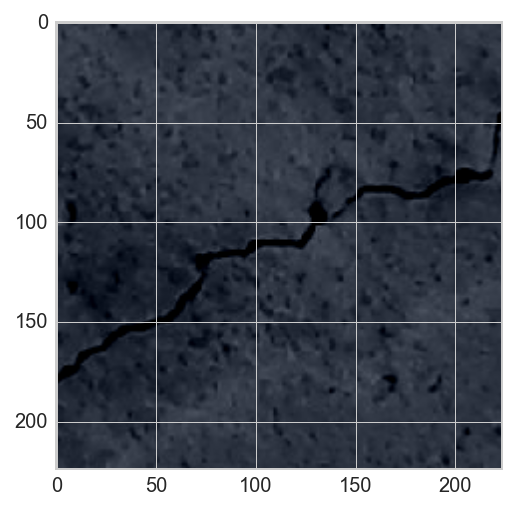

```python
plt.imshow(image.astype(int))
plt.show()
```

```
Clipping input data to the valid range for imshow with RGB data ([0..1] for floats or [0..255] for integers).
```

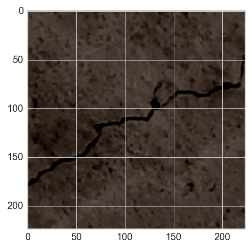

```python
plt.imshow(prepared_image.astype(int))
plt.show()
```

Finally, you may wish to use a model architecture on your dataset, but not use the pre-trained weights, and instead initialize the model with random weights and train the model **from scratch**.

This can be achieved by setting the `weights` argument to `None` instead of the default `imagenet`. Additionally, the `classes` argument can be set to define the number of classes in your dataset, which will then be configured for you in the output layer of the model. For example:

```python
# define a new model with random weights and 10 classes
new_input = tf.keras.Input(shape=(256, 256, 3))
model = VGG16(weights=None, input_tensor=new_input, classes=10)
model.summary()
```

```
Model: "vgg16"
_________________________________________________________________
Layer (type)                 Output Shape              Param #
=================================================================
input_4 (InputLayer)         [(None, 256, 256, 3)]     0
_________________________________________________________________
block1_conv1 (Conv2D)        (None, 256, 256, 64)      1792
_________________________________________________________________
block1_conv2 (Conv2D)        (None, 256, 256, 64)      36928
_________________________________________________________________
block1_pool (MaxPooling2D)   (None, 128, 128, 64)      0
_________________________________________________________________
block2_conv1 (Conv2D)        (None, 128, 128, 128)     73856
_________________________________________________________________
block2_conv2 (Conv2D)        (None, 128, 128, 128)     147584
_________________________________________________________________
block2_pool (MaxPooling2D)   (None, 64, 64, 128)       0
_________________________________________________________________
block3_conv1 (Conv2D)        (None, 64, 64, 256)       295168
_________________________________________________________________
block3_conv2 (Conv2D)        (None, 64, 64, 256)       590080
_________________________________________________________________
block3_conv3 (Conv2D)        (None, 64, 64, 256)       590080
_________________________________________________________________
block3_pool (MaxPooling2D)   (None, 32, 32, 256)       0
_________________________________________________________________
block4_conv1 (Conv2D)        (None, 32, 32, 512)       1180160
_________________________________________________________________
block4_conv2 (Conv2D)        (None, 32, 32, 512)       2359808
_________________________________________________________________
block4_conv3 (Conv2D)        (None, 32, 32, 512)       2359808
_________________________________________________________________
block4_pool (MaxPooling2D)   (None, 16, 16, 512)       0
_________________________________________________________________
block5_conv1 (Conv2D)        (None, 16, 16, 512)       2359808
_________________________________________________________________
block5_conv2 (Conv2D)        (None, 16, 16, 512)       2359808
_________________________________________________________________
block5_conv3 (Conv2D)        (None, 16, 16, 512)       2359808
_________________________________________________________________
block5_pool (MaxPooling2D)   (None, 8, 8, 512)         0
_________________________________________________________________
flatten (Flatten)            (None, 32768)             0
_________________________________________________________________
fc1 (Dense)                  (None, 4096)              134221824
_________________________________________________________________
fc2 (Dense)                  (None, 4096)              16781312
_________________________________________________________________
predictions (Dense)          (None, 10)                40970
=================================================================
Total params: 165,758,794
Trainable params: 165,758,794
Non-trainable params: 0
_________________________________________________________________
```

Note that training model from scratch may take hours.

# 5. Pre-trained Model as Classifer: Dog Image Example

## 5.1 Load the VGG16, InceptionV3 and ResNet50 Pre-trained Model

Different models may have different default input shape.

By default, VGG16 expects color input images to be rescaled to the size of 224×224 squares.

```python
# example of loading the vgg16 model
from tensorflow.keras.applications.vgg16 import VGG16
# load model
model = VGG16()
# summarize the model
model.get_layer(index=0).get_config()
```

```
{'batch_input_shape': (None, 224, 224, 3),
 'dtype': 'float32',
 'sparse': False,
 'name': 'input_5'}
```

InceptionV3 expects color images to have the square shape 299×299.

```python
from tensorflow.keras.applications.inception_v3 import InceptionV3
# load model
model = InceptionV3()
# summarize the model
model.get_layer(index=0).get_config()
```

```
{'batch_input_shape': (None, 299, 299, 3),
 'dtype': 'float32',
 'sparse': False,
 'name': 'input_6'}
```

ResNet50 expects color images to have the square shape 224×224.

```python
# example of loading the resnet50 model
from tensorflow.keras.applications.resnet50 import ResNet50
# load model
model = ResNet50()
# summarize the model
model.get_layer(index=0).get_config()
```

```
{'batch_input_shape': (None, 224, 224, 3),
 'dtype': 'float32',
 'sparse': False,
 'name': 'input_7'}
```

## 5.2 Load Dog Image

We will use the VGG16 model to classify new images.

```python
# load an image from file
image = tf.keras.preprocessing.image.load_img('dog.jpg', target_size=(224, 224))
type(image)
```

```
PIL.Image.Image
```

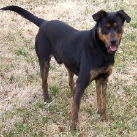

```python
image
```

```python
# convert the image pixels to a numpy array
image = tf.keras.preprocessing.image.img_to_array(image)
image
```

```
array([[[207., 187., 162.],
        [207., 187., 163.],
        [198., 180., 160.],
        ...,
        [231., 217., 180.],
        [238., 224., 187.],
        [228., 212., 176.]],

       [[201., 185., 160.],
        [207., 191., 168.],
        [196., 179., 159.],
        ...,
        [222., 210., 172.],
        [221., 209., 171.],
        [225., 211., 174.]],

       [[227., 215., 191.],
        [191., 176., 153.],
        [173., 158., 137.],
        ...,
        [203., 194., 155.],
        [224., 215., 176.],
        [208., 196., 158.]],

       ...,

       [[165., 146., 129.],
        [222., 183., 166.],
        [237., 199., 178.],
        ...,
        [215., 199., 174.],
        [188., 172., 146.],
        [179., 164., 133.]],

       [[150., 133., 113.],
        [177., 140., 122.],
        [205., 168., 150.],
        ...,
        [208., 192., 167.],
        [161., 145., 119.],
        [222., 207., 176.]],

       [[110.,  95.,  74.],
        [144., 108.,  94.],
        [180., 142., 129.],
        ...,
        [205., 189., 164.],
        [187., 171., 145.],
        [181., 166., 135.]]], dtype=float32)
```

```python
image.shape
```

```
(224, 224, 3)
```

The model operates on an array of samples, therefore the dimensions of a loaded image need to be expanded by 1, for one image with 224×224 pixels and three channels.

```python
from tensorflow.keras.applications.vgg16 import preprocess_input
# reshape data for the model
image = image.reshape((1, image.shape[0], image.shape[1], image.shape[2]))
# prepare the image for the VGG model
image = preprocess_input(image)
```

```python
image.shape
```

```
(1, 224, 224, 3)
```

```
Clipping input data to the valid range for imshow with RGB data ([0..1] for floats or [0..255] for integers).
```

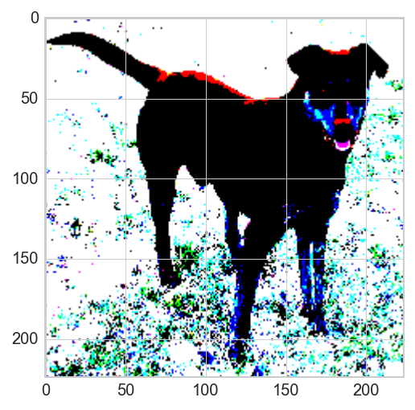

```python
plt.imshow(image[0])
plt.show()
```

## 5.3 Make Prediction

Since the model is already trained, we dont need to train it again.

Next, the model can be loaded and a prediction made.

This means that a predicted probability of the photo belonging to each of the 1,000 classes is made. In this example, we are only concerned with the most likely class, so we can decode the predictions and retrieve the label or name of the class with the highest probability.

```python
from tensorflow.keras.applications.vgg16 import VGG16
from tensorflow.keras.applications.vgg16 import decode_predictions
# predict the probability across all output classes
model = VGG16()
yhat = model.predict(image)
# convert the probabilities to class labels
label = decode_predictions(yhat)
# retrieve the most likely result, e.g. highest probability
label
```

```
[[('n02107142', 'Doberman', 0.35419154),
  ('n02105412', 'kelpie', 0.19439103),
  ('n02106550', 'Rottweiler', 0.1686235),
  ('n02089078', 'black-and-tan_coonhound', 0.13516615),
  ('n02107312', 'miniature_pinscher', 0.038150016)]]
```

# 6. Pre-Trained Model as Feature Extractor Preprocessor: Dog Image Example

Specifically, the extracted features of a photograph may be a vector of numbers that the model will use to describe the specific features in a photograph. These features can then be used as input in the development of a new model.

The last few layers of the model are fully connected layers prior to the output layer. These layers will provide a **complex set of features** to describe a given input image and may provide useful input when training a new model for image classification or related computer vision task.

This is normally done by loading the model with the classifier output part of the model, but manually remove the final output layer.

> In the example of VGG16. This means that the second last fully connected layer with 4,096 nodes will be the new output layer.

```python
# load model
model = VGG16()
# remove the output layer
model = tf.keras.Model(inputs=model.inputs, outputs=model.layers[-2].output)
model.summary()
```

```
Model: "model"
_________________________________________________________________
Layer (type)                 Output Shape              Param #
=================================================================
input_9 (InputLayer)         [(None, 224, 224, 3)]     0
_________________________________________________________________
block1_conv1 (Conv2D)        (None, 224, 224, 64)      1792
_________________________________________________________________
block1_conv2 (Conv2D)        (None, 224, 224, 64)      36928
_________________________________________________________________
block1_pool (MaxPooling2D)   (None, 112, 112, 64)      0
_________________________________________________________________
block2_conv1 (Conv2D)        (None, 112, 112, 128)     73856
_________________________________________________________________
block2_conv2 (Conv2D)        (None, 112, 112, 128)     147584
_________________________________________________________________
block2_pool (MaxPooling2D)   (None, 56, 56, 128)       0
_________________________________________________________________
block3_conv1 (Conv2D)        (None, 56, 56, 256)       295168
_________________________________________________________________
block3_conv2 (Conv2D)        (None, 56, 56, 256)       590080
_________________________________________________________________
block3_conv3 (Conv2D)        (None, 56, 56, 256)       590080
_________________________________________________________________
block3_pool (MaxPooling2D)   (None, 28, 28, 256)       0
_________________________________________________________________
block4_conv1 (Conv2D)        (None, 28, 28, 512)       1180160
_________________________________________________________________
block4_conv2 (Conv2D)        (None, 28, 28, 512)       2359808
_________________________________________________________________
block4_conv3 (Conv2D)        (None, 28, 28, 512)       2359808
_________________________________________________________________
block4_pool (MaxPooling2D)   (None, 14, 14, 512)       0
_________________________________________________________________
block5_conv1 (Conv2D)        (None, 14, 14, 512)       2359808
_________________________________________________________________
block5_conv2 (Conv2D)        (None, 14, 14, 512)       2359808
_________________________________________________________________
block5_conv3 (Conv2D)        (None, 14, 14, 512)       2359808
_________________________________________________________________
block5_pool (MaxPooling2D)   (None, 7, 7, 512)         0
_________________________________________________________________
flatten (Flatten)            (None, 25088)             0
_________________________________________________________________
fc1 (Dense)                  (None, 4096)              102764544
_________________________________________________________________
fc2 (Dense)                  (None, 4096)              16781312
=================================================================
Total params: 134,260,544
Trainable params: 134,260,544
Non-trainable params: 0
_________________________________________________________________
```

```python
# get extracted features
features = model.predict(image)
features.shape
```

```
(1, 4096)
```

```python
features
```

```
array([[-0., -0., -0., ..., -0., -0., -0.]], dtype=float32)
```

# 7. Pre-Trained Model as Feature Extractor in Model

This can be achieved by loading the model, then simply adding new layers. This may involve adding new convolutional and pooling layers to expand upon the feature extraction capabilities of the model or adding new fully connected classifier type layers to learn how to interpret the extracted features on a new dataset, or some combination.

```python
wide = x_train.shape[1]
length = x_train.shape[2]
x_train.shape
```

```
(11974, 224, 224, 3)
```

```python
# load model without classifier layers
model = VGG16(include_top=False, input_shape=(wide, length, 3))
model.summary()
```

```
Model: "vgg16"
_________________________________________________________________
Layer (type)                 Output Shape              Param #
=================================================================
input_10 (InputLayer)        [(None, 224, 224, 3)]     0
_________________________________________________________________
block1_conv1 (Conv2D)        (None, 224, 224, 64)      1792
_________________________________________________________________
block1_conv2 (Conv2D)        (None, 224, 224, 64)      36928
_________________________________________________________________
block1_pool (MaxPooling2D)   (None, 112, 112, 64)      0
_________________________________________________________________
block2_conv1 (Conv2D)        (None, 112, 112, 128)     73856
_________________________________________________________________
block2_conv2 (Conv2D)        (None, 112, 112, 128)     147584
_________________________________________________________________
block2_pool (MaxPooling2D)   (None, 56, 56, 128)       0
_________________________________________________________________
block3_conv1 (Conv2D)        (None, 56, 56, 256)       295168
_________________________________________________________________
block3_conv2 (Conv2D)        (None, 56, 56, 256)       590080
_________________________________________________________________
block3_conv3 (Conv2D)        (None, 56, 56, 256)       590080
_________________________________________________________________
block3_pool (MaxPooling2D)   (None, 28, 28, 256)       0
_________________________________________________________________
block4_conv1 (Conv2D)        (None, 28, 28, 512)       1180160
_________________________________________________________________
block4_conv2 (Conv2D)        (None, 28, 28, 512)       2359808
_________________________________________________________________
block4_conv3 (Conv2D)        (None, 28, 28, 512)       2359808
_________________________________________________________________
block4_pool (MaxPooling2D)   (None, 14, 14, 512)       0
_________________________________________________________________
block5_conv1 (Conv2D)        (None, 14, 14, 512)       2359808
_________________________________________________________________
block5_conv2 (Conv2D)        (None, 14, 14, 512)       2359808
_________________________________________________________________
block5_conv3 (Conv2D)        (None, 14, 14, 512)       2359808
_________________________________________________________________
block5_pool (MaxPooling2D)   (None, 7, 7, 512)         0
=================================================================
Total params: 14,714,688
Trainable params: 14,714,688
Non-trainable params: 0
_________________________________________________________________
```

Usually, we may wish to use the VGG16 model layers, but **train the new layers of the model without updating the weights of the VGG16 layers**. This will allow the new output layers to learn to interpret the learned features of the VGG16 model.

This can be achieved by setting the `trainable` property on each of the layers in the loaded VGG model to False prior to training. For example:

```python
# mark loaded layers as not trainable
for layer in model.layers:
    layer.trainable = False
```

We can then use the Keras function API to add a new `Flatten` layer after the last pooling layer in the VGG16 model, then define a new classifier model with a Dense fully connected layer and an output layer that will predict the probability for 2 classes.

```python
# add new classifier layers
flat1 = tf.keras.layers.Flatten()(model.layers[-1].output)
class1 = tf.keras.layers.Dense(1024, activation='relu')(flat1)
output = tf.keras.layers.Dense(2, activation='softmax')(class1)
# define new model
model = tf.keras.Model(inputs=model.inputs, outputs=output)
model.summary()
```

```
Model: "model_1"
_________________________________________________________________
Layer (type)                 Output Shape              Param #
=================================================================
input_10 (InputLayer)        [(None, 224, 224, 3)]     0
_________________________________________________________________
block1_conv1 (Conv2D)        (None, 224, 224, 64)      1792
_________________________________________________________________
block1_conv2 (Conv2D)        (None, 224, 224, 64)      36928
_________________________________________________________________
block1_pool (MaxPooling2D)   (None, 112, 112, 64)      0
_________________________________________________________________
block2_conv1 (Conv2D)        (None, 112, 112, 128)     73856
_________________________________________________________________
block2_conv2 (Conv2D)        (None, 112, 112, 128)     147584
_________________________________________________________________
block2_pool (MaxPooling2D)   (None, 56, 56, 128)       0
_________________________________________________________________
block3_conv1 (Conv2D)        (None, 56, 56, 256)       295168
_________________________________________________________________
block3_conv2 (Conv2D)        (None, 56, 56, 256)       590080
_________________________________________________________________
block3_conv3 (Conv2D)        (None, 56, 56, 256)       590080
_________________________________________________________________
block3_pool (MaxPooling2D)   (None, 28, 28, 256)       0
_________________________________________________________________
block4_conv1 (Conv2D)        (None, 28, 28, 512)       1180160
_________________________________________________________________
block4_conv2 (Conv2D)        (None, 28, 28, 512)       2359808
_________________________________________________________________
block4_conv3 (Conv2D)        (None, 28, 28, 512)       2359808
_________________________________________________________________
block4_pool (MaxPooling2D)   (None, 14, 14, 512)       0
_________________________________________________________________
block5_conv1 (Conv2D)        (None, 14, 14, 512)       2359808
_________________________________________________________________
block5_conv2 (Conv2D)        (None, 14, 14, 512)       2359808
_________________________________________________________________
block5_conv3 (Conv2D)        (None, 14, 14, 512)       2359808
_________________________________________________________________
block5_pool (MaxPooling2D)   (None, 7, 7, 512)         0
_________________________________________________________________
flatten (Flatten)            (None, 25088)             0
_________________________________________________________________
dense (Dense)                (None, 1024)              25691136
_________________________________________________________________
dense_1 (Dense)              (None, 2)                 2050
=================================================================
Total params: 40,407,874
Trainable params: 25,693,186
Non-trainable params: 14,714,688
_________________________________________________________________
```

You can pick and choose which layers are trainable.

For example, perhaps you want to retrain some of the convolutional layers deep in the model, but none of the layers earlier in the model. For example:

```python
# # mark some layers as not trainable
# model.get_layer('block1_conv1').trainable = False
```

# 8. Kaggle Crack Test - Feature Extraction

Extract Features Using VGG16:

```python
# load model
model = VGG16()
# remove the output layer
model = tf.keras.Model(inputs=model.inputs, outputs=model.layers[-2].output)
model.summary()
```

```
Model: "model_2"
_________________________________________________________________
Layer (type)                 Output Shape              Param #
=================================================================
input_11 (InputLayer)        [(None, 224, 224, 3)]     0
_________________________________________________________________
block1_conv1 (Conv2D)        (None, 224, 224, 64)      1792
_________________________________________________________________
block1_conv2 (Conv2D)        (None, 224, 224, 64)      36928
_________________________________________________________________
block1_pool (MaxPooling2D)   (None, 112, 112, 64)      0
_________________________________________________________________
block2_conv1 (Conv2D)        (None, 112, 112, 128)     73856
_________________________________________________________________
block2_conv2 (Conv2D)        (None, 112, 112, 128)     147584
_________________________________________________________________
block2_pool (MaxPooling2D)   (None, 56, 56, 128)       0
_________________________________________________________________
block3_conv1 (Conv2D)        (None, 56, 56, 256)       295168
_________________________________________________________________
block3_conv2 (Conv2D)        (None, 56, 56, 256)       590080
_________________________________________________________________
block3_conv3 (Conv2D)        (None, 56, 56, 256)       590080
_________________________________________________________________
block3_pool (MaxPooling2D)   (None, 28, 28, 256)       0
_________________________________________________________________
block4_conv1 (Conv2D)        (None, 28, 28, 512)       1180160
_________________________________________________________________
block4_conv2 (Conv2D)        (None, 28, 28, 512)       2359808
_________________________________________________________________
block4_conv3 (Conv2D)        (None, 28, 28, 512)       2359808
_________________________________________________________________
block4_pool (MaxPooling2D)   (None, 14, 14, 512)       0
_________________________________________________________________
block5_conv1 (Conv2D)        (None, 14, 14, 512)       2359808
_________________________________________________________________
block5_conv2 (Conv2D)        (None, 14, 14, 512)       2359808
_________________________________________________________________
block5_conv3 (Conv2D)        (None, 14, 14, 512)       2359808
_________________________________________________________________
block5_pool (MaxPooling2D)   (None, 7, 7, 512)         0
_________________________________________________________________
flatten (Flatten)            (None, 25088)             0
_________________________________________________________________
fc1 (Dense)                  (None, 4096)              102764544
_________________________________________________________________
fc2 (Dense)                  (None, 4096)              16781312
=================================================================
Total params: 134,260,544
Trainable params: 134,260,544
Non-trainable params: 0
_________________________________________________________________
```

Original feature length:

```python
wide * length
```

```
50176
```

```python
# get extracted features for train set
features_train = model.predict(x_train)
features.shape
```

```
(1, 4096)
```

```python
# get extracted features for test set
features_test = model.predict(x_test)
features.shape
```

```
(1, 4096)
```

Build Model:

```python
def FNN_Model():
    model = tf.keras.models.Sequential()
    model.add(tf.keras.layers.Flatten())
    model.add(tf.keras.layers.Dense(1,activation=tf.nn.sigmoid))
    model.compile(optimizer='adam',loss=tf.keras.losses.BinaryCrossentropy(),
                  metrics=[tf.keras.metrics.BinaryAccuracy(),
                          tf.keras.metrics.Precision(),
                          tf.keras.metrics.TruePositives()])
    return model

model = FNN_Model()
```

```python
model.fit(features_train,y_train,epochs=5)
```

```
Train on 11974 samples
```

```
<tensorflow.python.keras.callbacks.History at 0x7fd1627588d0>
```

```python
model.summary()
```

```
Model: "sequential"
_________________________________________________________________
Layer (type)                 Output Shape              Param #
=================================================================
flatten_1 (Flatten)          multiple                  0
_________________________________________________________________
dense_2 (Dense)              multiple                  4097
=================================================================
Total params: 4,097
Trainable params: 4,097
Non-trainable params: 0
_________________________________________________________________
```

Evaluation:

```python
%%capture
val_loss, val_acc, val_pre, val_TP = model.evaluate(features_test,y_test)
```

```python
result = {}
result["original"] = [val_loss, val_acc, val_pre, val_TP/(y_test == 1).sum()]
val_loss, val_acc, val_pre, val_TP/(y_test == 1).sum()
```

```
(0.43844254944988625, 0.79358715, 0.8172119, 0.7609271523178808)
```

```python
import pandas as pd
result = pd.DataFrame(result)
result.index = ["loss", "Accuracy", "Precision", "TPR"]
result
```

|  | original |
| --- | --- |
| loss | 0.438443 |
| Accuracy | 0.793587 |
| Precision | 0.817212 |
| TPR | 0.760927 |